# Moloco

Alice Young

February 19, 2020

```r
library(dplyr)
library(lubridate)
```

```r
library(ggplot2)
```

# Analytics

```r
dat = read.csv('moloco.csv')
```

## Problem 1

I filtered the data frame for rows that have a country_id of BDV. I grouped by site_id and counted the number of unique ids for each site_id. I then arranged it in descending order by the number of unique ids to get the site_id with the largest number of unique users in the first row of the outputted data frame.

```r
dat %>% filter(country_id == 'BDV') %>%
  group_by(site_id) %>%
  summarise(unique_ids = n_distinct(user_id)) %>%
  arrange(desc(unique_ids))
```

```
## # A tibble: 3 x 2
##   site_id unique_ids
##   <fct>        <int>
## 1 5NPAU          544
## 2 N0OTG           90
## 3 3POLC            2
```

## Problem 2

I first limited the data frame to only entries that fall between the desired time frame. I then grouped by user_id and site_id so I could count the number of times each user visited each site. I arranged this data in descending order by the number of visits to get the users who visited a certain site more than 10 times in the first four rows.

```r
dat %>% filter(as.Date(ts) >= as.Date('2019-02-03') & as.Date(ts) <= as.Date('2019-02-04')) %>%
  group_by(user_id, site_id) %>%
  summarise(num_visits = length(ts)) %>%
  arrange(desc(num_visits))
```

```
## # A tibble: 746 x 3
## # Groups:   user_id [708]
##    user_id site_id num_visits
##    <fct>   <fct>        <int>
##  1 LC3A59  N0OTG           26
##  2 LC06C3  N0OTG           25
##  3 LC3C9D  N0OTG           17
##  4 LC3C7E  3POLC           15
##  5 LC38EB  N0OTG            9
##  6 LCC3A5  5NPAU            8
##  7 LC3FFF  5NPAU            7
##  8 LC32F5  N0OTG            6
##  9 LC3491  5NPAU            6
## 10 LC36FC  N0OTG            6
## # … with 736 more rows
```

## Problem 3

I grouped by user_id and selected the most recent row for each user. I then grouped by site_id to count the number of users whose last visit was to that site. I arranged this in descending order by the number of visitors to get the top 3 sites in the first 3 rows.

```r
dat %>% group_by(user_id) %>%
  slice(which.max(as.Date(ts))) %>%
  group_by(site_id) %>%
  summarise(num_visitors = length(user_id)) %>%
  arrange(desc(num_visitors))
```

```
## # A tibble: 7 x 2
##   site_id num_visitors
##   <fct>          <int>
## 1 5NPAU            986
## 2 N0OTG            561
## 3 QGO3G            295
## 4 GVOFK             43
## 5 3POLC             29
## 6 JSUUP              1
## 7 RT9Z6              1
```

## Problem 4

I grouped by user_id and selected each user’s earliest and latest visits. For each user, I then counted the number of different site_ids they had. If this number was 1, then that means the first site they visited was also the last site they visited. If this number was 2, then their first site was not their last site. Since the first metric is the number that we are interested in, I counted the number of users whose number of different site_ids is 1.

```r
dat %>% group_by(user_id) %>%
  slice(which.min(as.Date(ts)), which.max(as.Date(ts))) %>%
  summarise(diff = n_distinct(site_id)) %>%
  filter(diff == 1) %>%
  nrow
```

```
## [1] 1694
```

# Regression

```r
dat2 = read.csv('dat2.csv', col.names=c('A','B','C'))
```

First, I want to see whether there are any outliers in the dataset. To do this, I plot each of the independent variables against column C.

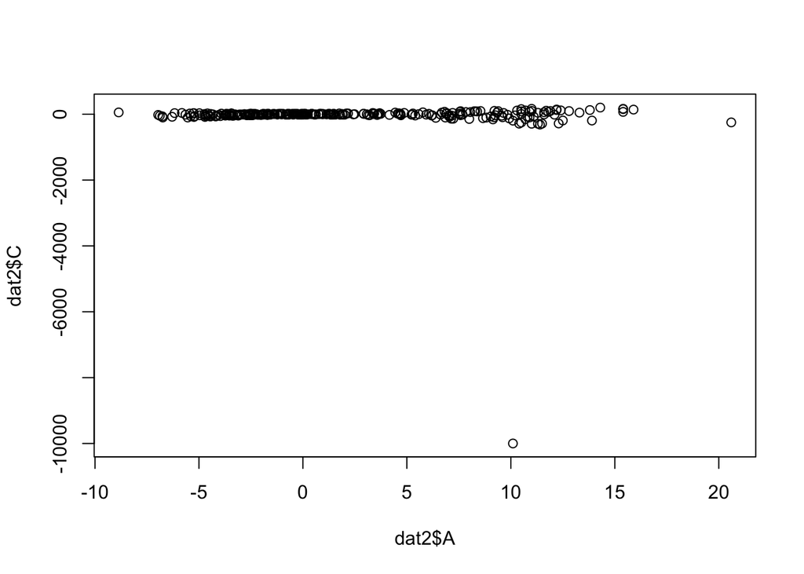

```r
plot(dat2$A, dat2$C)
```

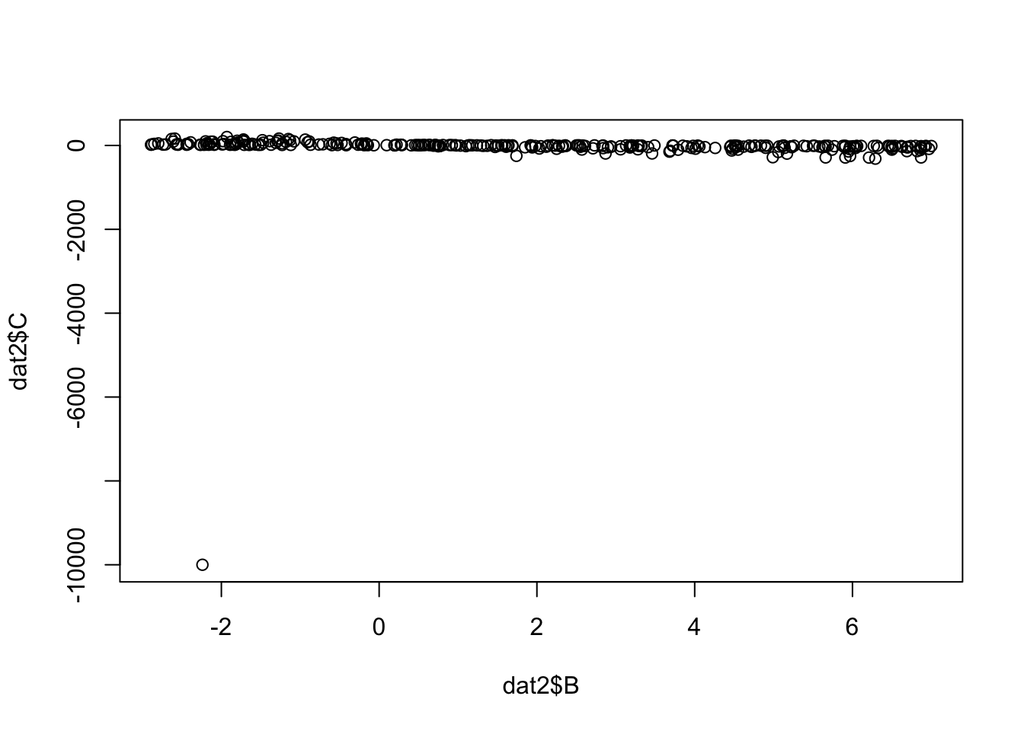

```r
plot(dat2$B, dat2$C)
```

We see that there is indeed an outlier, at the value of -10,000 in column C. We remove this value before we try to fit a model.

```r
no_outliers = filter(dat2, dat2$C != -10000)
```

```r
library(caret)
```

I create a training set and a test set to test for overfitting. I select 80% of the data to be in the training set and reserve the remaining 20% for the test set.

```r
set.seed(1000)
partition <- createDataPartition(no_outliers[, 1], list = FALSE, p = 0.80)
trainGLM <- no_outliers[partition, ]
testGLM <- no_outliers[-partition, ]
```

## Model 1

```r
glm1 <- glm(C ~ A + B, family = gaussian, data = no_outliers)
summary(glm1)
```

```
##
## Call:
## glm(formula = C ~ A + B, family = gaussian, data = no_outliers)
##
## Deviance Residuals:
##      Min        1Q    Median        3Q       Max
## -229.354   -26.468     1.858    32.974   166.374
##
## Coefficients:
##             Estimate Std. Error t value Pr(>|t|)
## (Intercept)  25.8280     4.2831   6.030 4.89e-09 ***
## A            -1.3713     0.5788  -2.369   0.0185 *
## B           -15.2371     1.1003 -13.848  < 2e-16 ***
## ---
## Signif. codes:  0 '***' 0.001 '**' 0.01 '*' 0.05 '.' 0.1 ' ' 1
##
## (Dispersion parameter for gaussian family taken to be 3112.935)
##
##     Null deviance: 1515477  on 297  degrees of freedom
## Residual deviance:  918316  on 295  degrees of freedom
## AIC: 3247.6
##
## Number of Fisher Scoring iterations: 2
```

Then, I use the model to make predictions with the testing data and 1) compare the train rmse to the test rmse, and 2) look at the AIC value (found above), which are the metrics that I will be using to evaluate the performance of my models.

```r
predict.glm1.train <- predict(glm1, type = "response")
predict.glm1.test <- predict(glm1, newdata = testGLM, type = "response")
rmsetrain <- sqrt(sum((predict.glm1.train - trainGLM$C)^2)/nrow(trainGLM))
rmsetest <- sqrt(sum((predict.glm1.test - testGLM$C)^2)/nrow(testGLM))
print("Prediction error of training and test sets")
```

```
## [1] "Prediction error of training and test sets"
```

```r
rmsetrain
```

```
## [1] 87.11963
```

```r
rmsetest
```

```
## [1] 46.58816
```

## Model 2

Similarly, for model 2, I train a generalized linear model on column C but this time as a function of the sum of columns A, B, and column A x column B.

```r
glm2 <- glm(C ~ A + B + A:B, family = gaussian, data = trainGLM)
summary(glm2)
```

```
##
## Call:
## glm(formula = C ~ A + B + A:B, family = gaussian, data = trainGLM)
##
## Deviance Residuals:
##      Min        1Q    Median        3Q       Max
## -185.695   -14.020     0.714    23.127    80.242
##
## Coefficients:
##             Estimate Std. Error t value Pr(>|t|)
## (Intercept)  14.0416     3.3941   4.137 4.89e-05 ***
## A             1.8102     0.4980   3.635 0.000341 ***
## B           -10.7103     0.8792 -12.182  < 2e-16 ***
## A:B          -2.6504     0.1517 -17.469  < 2e-16 ***
## ---
## Signif. codes:  0 '***' 0.001 '**' 0.01 '*' 0.05 '.' 0.1 ' ' 1
##
## (Dispersion parameter for gaussian family taken to be 1454.658)
##
##     Null deviance: 1293062  on 239  degrees of freedom
## Residual deviance:  343299  on 236  degrees of freedom
## AIC: 2434.9
##
## Number of Fisher Scoring iterations: 2
```

```r
predict.glm2.train <- predict(glm2, type = "response")
predict.glm2.test <- predict(glm2, newdata = testGLM, type = "response")
rmsetrain <- sqrt(sum((predict.glm2.train - trainGLM$C)^2)/nrow(trainGLM))
rmsetest <- sqrt(sum((predict.glm2.test - testGLM$C)^2)/nrow(testGLM))
print("Prediction error of training and test sets")
```

```
## [1] "Prediction error of training and test sets"
```

```r
rmsetrain
```

```
## [1] 37.82081
```

```r
rmsetest
```

```
## [1] 34.82695
```

We see that both the training and test errors are lower than those for model 1. Also, the AIC value is 812.7 lower. This means that model 2 is overall a better model.

## Model 3

Model 3 fits column C as a function of column A x column B.

```r
glm3 <- glm(C ~ A:B, family = gaussian, data = trainGLM)
summary(glm3)
```

```
##
## Call:
## glm(formula = C ~ A:B, family = gaussian, data = trainGLM)
##
## Deviance Residuals:
##     Min       1Q   Median       3Q      Max
## -195.91   -15.20    13.79    24.91   129.61
##
## Coefficients:
##             Estimate Std. Error t value Pr(>|t|)
## (Intercept)  -4.8023     3.3616  -1.429    0.154
## A:B          -2.7969     0.1782 -15.699   <2e-16 ***
## ---
## Signif. codes:  0 '***' 0.001 '**' 0.01 '*' 0.05 '.' 0.1 ' ' 1
##
## (Dispersion parameter for gaussian family taken to be 2669.158)
##
##     Null deviance: 1293062  on 239  degrees of freedom
## Residual deviance:  635260  on 238  degrees of freedom
## AIC: 2578.6
##
## Number of Fisher Scoring iterations: 2
```

```r
predict.glm3.train <- predict(glm3, type = "response")
predict.glm3.test <- predict(glm3, newdata = testGLM, type = "response")
rmsetrain <- sqrt(sum((predict.glm3.train - trainGLM$C)^2)/nrow(trainGLM))
rmsetest <- sqrt(sum((predict.glm3.test - testGLM$C)^2)/nrow(testGLM))
print("Prediction error of training and test sets")
```

```
## [1] "Prediction error of training and test sets"
```

```r
rmsetrain
```

```
## [1] 51.44818
```

```r
rmsetest
```

```
## [1] 54.33129
```

Both the training and test errors are higher than those for Model 2, and the AIC is higher as well. So, Model 2 is still the best model so far.

## Model 4

Model 4 fits column C as the sum of column A and column A x column B.

```r
glm4 <- glm(C ~ A + A:B, family = gaussian, data = trainGLM)
summary(glm4)
```

```
##
## Call:
## glm(formula = C ~ A + A:B, family = gaussian, data = trainGLM)
##
## Deviance Residuals:
##     Min       1Q   Median       3Q      Max
## -192.11   -11.19    13.36    22.83   149.37
##
## Coefficients:
##             Estimate Std. Error t value Pr(>|t|)
## (Intercept) -11.6781     3.3846  -3.450 0.000662 ***
## A             3.4646     0.6102   5.678 3.96e-08 ***
## A:B          -3.2246     0.1837 -17.557  < 2e-16 ***
## ---
## Signif. codes:  0 '***' 0.001 '**' 0.01 '*' 0.05 '.' 0.1 ' ' 1
##
## (Dispersion parameter for gaussian family taken to be 2359.435)
##
##     Null deviance: 1293062  on 239  degrees of freedom
## Residual deviance:  559186  on 237  degrees of freedom
## AIC: 2550
##
## Number of Fisher Scoring iterations: 2
```

```r
predict.glm4.train <- predict(glm4, type = "response")
predict.glm4.test <- predict(glm4, newdata = testGLM, type = "response")
rmsetrain <- sqrt(sum((predict.glm4.train - trainGLM$C)^2)/nrow(trainGLM))
rmsetest <- sqrt(sum((predict.glm4.test - testGLM$C)^2)/nrow(testGLM))
print("Prediction error of training and test sets")
```

```
## [1] "Prediction error of training and test sets"
```

```r
rmsetrain
```

```
## [1] 48.26948
```

```r
rmsetest
```

```
## [1] 46.15096
```

Model 2 is still the best model.

## Model 5

Model 5 fits column C as a function of the sum of column B and column A x column B.

```r
glm5 <- glm(C ~ B + A:B, family = gaussian, data = trainGLM)
summary(glm5)
```

```
##
## Call:
## glm(formula = C ~ B + A:B, family = gaussian, data = trainGLM)
##
## Deviance Residuals:
##     Min       1Q   Median       3Q      Max
## -161.40   -18.74     2.69    24.66    94.04
##
## Coefficients:
##             Estimate Std. Error t value Pr(>|t|)
## (Intercept)  19.4598     3.1268   6.223 2.19e-09 ***
## B           -11.5819     0.8674 -13.353  < 2e-16 ***
## B:A          -2.3968     0.1382 -17.348  < 2e-16 ***
## ---
## Signif. codes:  0 '***' 0.001 '**' 0.01 '*' 0.05 '.' 0.1 ' ' 1
##
## (Dispersion parameter for gaussian family taken to be 1529.624)
##
##     Null deviance: 1293062  on 239  degrees of freedom
## Residual deviance:  362521  on 237  degrees of freedom
## AIC: 2445.9
##
## Number of Fisher Scoring iterations: 2
```

```r
predict.glm5.train <- predict(glm5, type = "response")
predict.glm5.test <- predict(glm5, newdata = testGLM, type = "response")
rmsetrain <- sqrt(sum((predict.glm5.train - trainGLM$C)^2)/nrow(trainGLM))
rmsetest <- sqrt(sum((predict.glm5.test - testGLM$C)^2)/nrow(testGLM))
print("Prediction error of training and test sets")
```

```
## [1] "Prediction error of training and test sets"
```

```r
rmsetrain
```

```
## [1] 38.8652
```

```r
rmsetest
```

```
## [1] 38.29322
```

Model 2 remains the best model.

## Model 6

For Models 6 and 7 below, both train and test errors are relatively high. This makes sense because both models only use one of the variables to fit the data in column C.

```r
glm6 <- glm(C ~ A, family = gaussian, data = trainGLM)
summary(glm6)
```

```
##
## Call:
## glm(formula = C ~ A, family = gaussian, data = trainGLM)
##
## Deviance Residuals:
##      Min        1Q    Median        3Q       Max
## -295.092   -12.981     5.725    24.429   224.601
##
## Coefficients:
##             Estimate Std. Error t value Pr(>|t|)
## (Intercept)  -9.3229     5.1188  -1.821   0.0698 .
## A            -0.9285     0.8423  -1.102   0.2714
## ---
## Signif. codes:  0 '***' 0.001 '**' 0.01 '*' 0.05 '.' 0.1 ' ' 1
##
## (Dispersion parameter for gaussian family taken to be 5405.434)
##
##     Null deviance: 1293062  on 239  degrees of freedom
## Residual deviance: 1286493  on 238  degrees of freedom
## AIC: 2747.9
##
## Number of Fisher Scoring iterations: 2
```

```r
predict.glm6.train <- predict(glm6, type = "response")
predict.glm6.test <- predict(glm6, newdata = testGLM, type = "response")
rmsetrain <- sqrt(sum((predict.glm6.train - trainGLM$C)^2)/nrow(trainGLM))
rmsetest <- sqrt(sum((predict.glm6.test - testGLM$C)^2)/nrow(testGLM))
print("Prediction error of training and test sets")
```

```
## [1] "Prediction error of training and test sets"
```

```r
rmsetrain
```

```
## [1] 73.21467
```

```r
rmsetest
```

```
## [1] 64.67982
```

## Model 7

```r
glm7 <- glm(C ~ B, family = gaussian, data = trainGLM)
summary(glm7)
```

```
##
## Call:
## glm(formula = C ~ B, family = gaussian, data = trainGLM)
##
## Deviance Residuals:
##      Min        1Q    Median        3Q       Max
## -243.047   -21.099     1.621    36.399   152.472
##
## Coefficients:
##             Estimate Std. Error t value Pr(>|t|)
## (Intercept)   20.877      4.699   4.442 1.36e-05 ***
## B            -14.845      1.273 -11.662  < 2e-16 ***
## ---
## Signif. codes:  0 '***' 0.001 '**' 0.01 '*' 0.05 '.' 0.1 ' ' 1
##
## (Dispersion parameter for gaussian family taken to be 3457.457)
##
##     Null deviance: 1293062  on 239  degrees of freedom
## Residual deviance:  822875  on 238  degrees of freedom
## AIC: 2640.7
##
## Number of Fisher Scoring iterations: 2
```

```r
predict.glm7.train <- predict(glm7, type = "response")
predict.glm7.test <- predict(glm7, newdata = testGLM, type = "response")
rmsetrain <- sqrt(sum((predict.glm7.train - trainGLM$C)^2)/nrow(trainGLM))
rmsetest <- sqrt(sum((predict.glm7.test - testGLM$C)^2)/nrow(testGLM))
print("Prediction error of training and test sets")
```

```
## [1] "Prediction error of training and test sets"
```

```r
rmsetrain
```

```
## [1] 58.55463
```

```r
rmsetest
```

```
## [1] 44.18656
```

I want a model that captures the general trend but is also generalizable enough to perform on unseen data. Such a model is Model 2: column C ~ column A + column B + column A x column B. Compared to the other 6 models, Model 2 has the lowest training error, test error, and AIC.

We now use this selected model (Model 2) on the entire dataset.

```r
glm2final <- glm(C ~ A + B + A:B, family = gaussian, data = no_outliers)
```

To visualize how these predicted values compare to the actual values, we make a scatter plot:

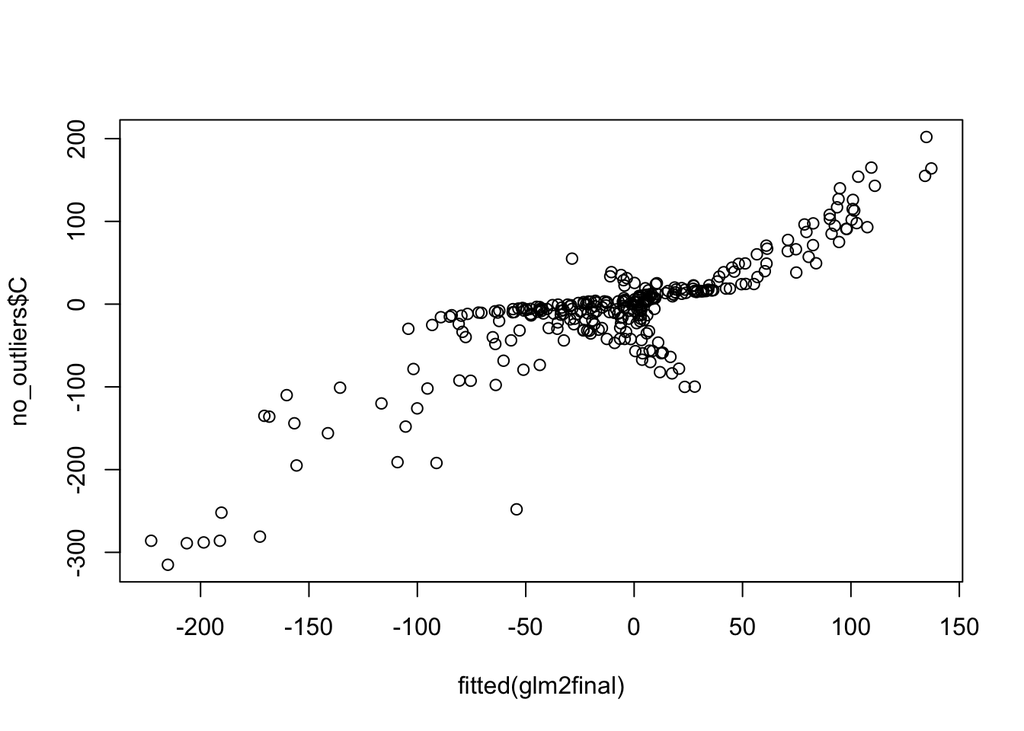

```r
plot(fitted(glm2final), no_outliers$C)
```